# EDA - Predicting Mental Health Outcomes from Music Listening Behaviour

### Necessary Libraries

```python
# Data manipulation
import pandas as pd
import numpy as np

# Visualization
import matplotlib.pyplot as plt
import seaborn as sns
import missingno as msno

# Display settings
pd.set_option('display.max_columns', None)
sns.set(style='whitegrid')

# For inline plots in Jupyter Notebook
%matplotlib inline
```

### 1. Music and Mental Health Dataset

```python
# Load the dataset
df = pd.read_csv('../data/mxmh_survey_results.csv')

# Basic information
print("Shape of the dataset:", df.shape)
print("\nFirst 5 rows of the dataset:")
display(df.head())
```

```
Shape of the dataset: (736, 33)

First 5 rows of the dataset:
```

|  | Timestamp | Age | Primary streaming service | Hours per day | While working | Instrumentalist | Composer | Fav genre | Exploratory | Foreign languages | BPM | Frequency [Classical] | Frequency [Country] | Frequency [EDM] | Frequency [Folk] | Frequency [Gospel] | Frequency [Hip hop] | Frequency [Jazz] | Frequency [K pop] | Frequency [Latin] | Frequency [Lofi] | Frequency [Metal] | Frequency [Pop] | Frequency [R&B] | Frequency [Rap] | Frequency [Rock] | Frequency [Video game music] | Anxiety | Depression | … |
| --- | --- | --- | --- | --- | --- | --- | --- | --- | --- | --- | --- | --- | --- | --- | --- | --- | --- | --- | --- | --- | --- | --- | --- | --- | --- | --- | --- | --- | --- | --- |
| 0 | 8/27/2022 19:29:02 | 18.0 | Spotify | 3.0 | Yes | Yes | Yes | Latin | Yes | Yes | 156.0 | Rarely | Never | Rarely | Never | Never | Sometimes | Never | Very frequently | Very frequently | Rarely | Never | Very frequently | Sometimes | Very frequently | Never | Sometimes | 3.0 | 0.0 | … |
| 1 | 8/27/2022 19:57:31 | 63.0 | Pandora | 1.5 | Yes | No | No | Rock | Yes | No | 119.0 | Sometimes | Never | Never | Rarely | Sometimes | Rarely | Very frequently | Rarely | Sometimes | Rarely | Never | Sometimes | Sometimes | Rarely | Very frequently | Rarely | 7.0 | 2.0 | … |
| 2 | 8/27/2022 21:28:18 | 18.0 | Spotify | 4.0 | No | No | No | Video game music | No | Yes | 132.0 | Never | Never | Very frequently | Never | Never | Rarely | Rarely | Very frequently | Never | Sometimes | Sometimes | Rarely | Never | Rarely | Rarely | Very frequently | 7.0 | 7.0 | … |
| 3 | 8/27/2022 21:40:40 | 61.0 | YouTube Music | 2.5 | Yes | No | Yes | Jazz | Yes | Yes | 84.0 | Sometimes | Never | Never | Rarely | Sometimes | Never | Very frequently | Sometimes | Very frequently | Sometimes | Never | Sometimes | Sometimes | Never | Never | Never | 9.0 | 7.0 | … |
| 4 | 8/27/2022 21:54:47 | 18.0 | Spotify | 4.0 | Yes | No | No | R&B | Yes | No | 107.0 | Never | Never | Rarely | Never | Rarely | Very frequently | Never | Very frequently | Sometimes | Sometimes | Never | Sometimes | Very frequently | Very frequently | Never | Rarely | 7.0 | 2.0 | … |

```python
# Column names
print("\nColumn Names:")
print(df.columns.tolist())

# Overview of data types and missing values
print("\nDataset Info:")
df.info()
```

```
Column Names:
['Timestamp', 'Age', 'Primary streaming service', 'Hours per day', 'While working', 'Instrumentalist', 'Composer', 'Fav genre', 'Exploratory', 'Foreign languages', 'BPM', 'Frequency [Classical]', 'Frequency [Country]', 'Frequency [EDM]', 'Frequency [Folk]', 'Frequency [Gospel]', 'Frequency [Hip hop]…

Dataset Info:
<class 'pandas.core.frame.DataFrame'>
RangeIndex: 736 entries, 0 to 735
Data columns (total 33 columns):
 #   Column                        Non-Null Count  Dtype
---  ------                        --------------  -----
 0   Timestamp                     736 non-null    object
 1   Age                           735 non-null    float64
 2   Primary streaming service     735 non-null    object
 3   Hours per day                 736 non-null    float64
 4   While working                 733 non-null    object
 5   Instrumentalist               732 non-null    object
```

[output cut: 29 more lines]

```python
# Summary statistics for numeric features
print("\nSummary Statistics:")
display(df.describe())
```

```
Summary Statistics:
```

|  | Age | Hours per day | BPM | Anxiety | Depression | Insomnia | OCD |
| --- | --- | --- | --- | --- | --- | --- | --- |
| count | 735.000000 | 736.000000 | 6.290000e+02 | 736.000000 | 736.000000 | 736.000000 | 736.000000 |
| mean | 25.206803 | 3.572758 | 1.589948e+06 | 5.837636 | 4.796196 | 3.738451 | 2.637228 |
| std | 12.054970 | 3.028199 | 3.987261e+07 | 2.793054 | 3.028870 | 3.088689 | 2.842017 |
| min | 10.000000 | 0.000000 | 0.000000e+00 | 0.000000 | 0.000000 | 0.000000 | 0.000000 |
| 25% | 18.000000 | 2.000000 | 1.000000e+02 | 4.000000 | 2.000000 | 1.000000 | 0.000000 |
| 50% | 21.000000 | 3.000000 | 1.200000e+02 | 6.000000 | 5.000000 | 3.000000 | 2.000000 |
| 75% | 28.000000 | 5.000000 | 1.440000e+02 | 8.000000 | 7.000000 | 6.000000 | 5.000000 |
| max | 89.000000 | 24.000000 | 1.000000e+09 | 10.000000 | 10.000000 | 10.000000 | 10.000000 |

If we examine the summary statistics for the MxMH data, we had a wide age range among participants, from 10 to 89 years, with median age approximately 21. On average, individuals reported listening to music for about 3.5 hours a day, though it did fluctuate significantly—some listened for less than an hour, while others listened almost the entire day (up to 24 hours, which is suspect or background music). The 0 to 10 scores for mental health indicate anxiety and depression as the most common, with higher-than-average scores of over 4 for both. The median anxiety score was 6, indicating that the majority of users have regular anxiety. The insomnia and OCD scores were lower overall but also commonly experienced by users.

One thing we wonder about is the BPM (beats per minute) column—it looks like it has some exceedingly high numbers (e.g., 1 billion), and that makes it seem like individuals may have gotten those wrong or responded in inconsistent ways to that question. We will likely need to clean or drop that variable before we can utilize it in our analysis. Together, these numbers already indicate a good degree of variation in music behavior and mental health, and on this basis further research is promising.

### 2. Missing Data Analysis

|  | Missing Values | Percentage (%) |
| --- | --- | --- |
| BPM | 107 | 14.54 |
| Music effects | 8 | 1.09 |
| Instrumentalist | 4 | 0.54 |
| Foreign languages | 4 | 0.54 |
| While working | 3 | 0.41 |
| Age | 1 | 0.14 |
| Primary streaming service | 1 | 0.14 |
| Composer | 1 | 0.14 |

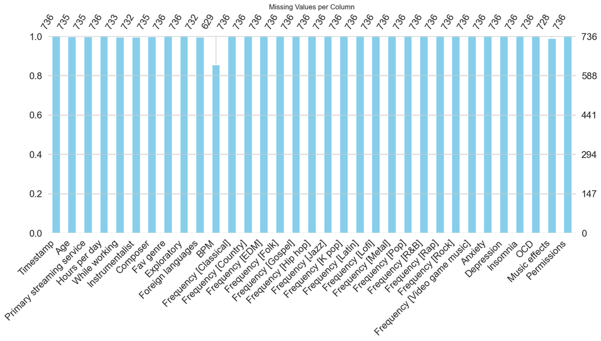

```python
# Checking number and percentage of missing values per column
missing_counts = df.isnull().sum()
missing_percent = (missing_counts / len(df)) * 100
missing_summary = pd.DataFrame({
    'Missing Values': missing_counts,
    'Percentage (%)': missing_percent.round(2)
})
display(missing_summary[missing_summary['Missing Values'] > 0].sort_values(by='Percentage (%)', ascending=False))

# Visualizing missingness using a bar chart
msno.bar(df, figsize=(16, 6), color="skyblue")
plt.title("Missing Values per Column")
plt.xticks(rotation=60, ha='right')
plt.savefig('../plots/1. Missing_Values_per_Column.png')
plt.show()
```

In trying to find missing values for the MxMH data set, there are very well-structured columns with very negligible missing values. The only column outside the trend is BPM (beats per minute) missing in about 15% of the responses. That is a fact and reminds us of two things—first, whether the question would be comprehensible to participants, and second, whether input data is reliable because the previous summary statistics were already detecting anomalously high outliers in BPM.

These other variables with less than 1.1% missing values and in our opinion can be filled or replaced with the mode without causing any harm since they are nominal variables are few of the ones like Music effects, Instrumentalist, and Foreign languages. Likewise, During work, Age, and Primary streaming service with 1–3 missing observations respectively is not significant when handling data this large. We plan to fill these based on either the mode (for categorical) or median (for numerical like age).

As for the BPM column, considering its high missing rate and outliers, we’re currently leaning toward either dropping it entirely or treating it separately with robust imputation and outlier filtering, depending on how useful it proves to be during model evaluation.

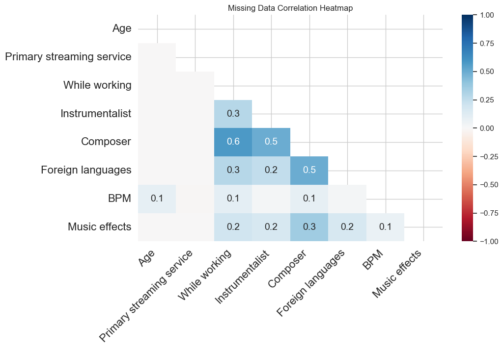

```python
# Heatmap of missingness correlation
msno.heatmap(df, figsize=(10, 6))
plt.title("Missing Data Correlation Heatmap")
plt.savefig('../plots/2. Missing_Data_Correlation_Heatmap.png')
plt.show()
```

### 3. Univariate Analysis

#### Music Listening Behavior

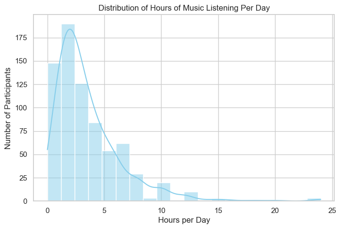

```python
# Distribution of hours per day
plt.figure(figsize=(8,5))
sns.histplot(df['Hours per day'], kde=True, bins=20, color='skyblue')
plt.title('Distribution of Hours of Music Listening Per Day')
plt.xlabel('Hours per Day')
plt.ylabel('Number of Participants')
plt.savefig('../plots/3. Distribution_of_Hours_of_Music_Listening_Per_Day.png')
plt.show()
```

From the analysis of music listening hours, it can be noted that most of the survey respondents listen to music for 1 to 4 hours daily, with a sharp peak in the 2-hour figure. The distribution is to the right, indicating that while most fall in the moderate listening group, there are some who listen for 10 or more hours per day — possibly from use of music at work, during sleep, or passive background listening. There are a couple of outliers somewhat surprisingly going as high as 24 hours, perhaps reflecting exaggerations or autoplay/streaming usage. This bias will be useful to remember later when analyzing what correlation listening time has with mental health scores.

#### Age of Participants

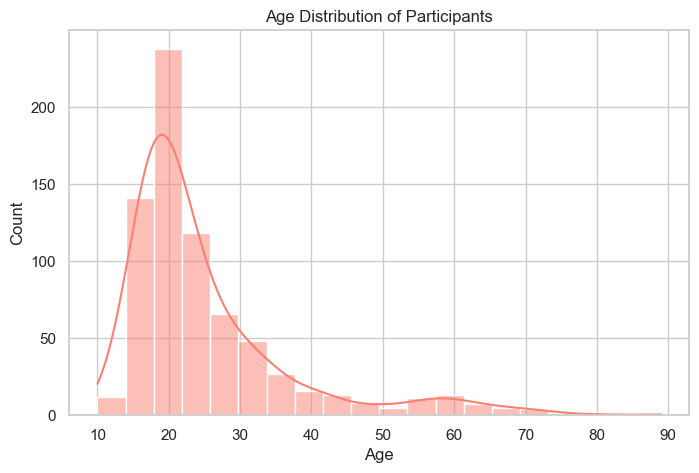

```python
# Histogram of Age
plt.figure(figsize=(8,5))
sns.histplot(df['Age'], kde=True, bins=20, color='salmon')
plt.title('Age Distribution of Participants')
plt.xlabel('Age')
plt.ylabel('Count')
plt.savefig('../plots/4. Age_Distribution_of_Participants.png')
plt.show()
```

Our population demographics based on age provide information that the largest category of respondents is between the ages of 15 to 30 years, and their highest frequency is from 18 to 22 years. The curve of distribution is highly right-skewed, supporting evidence that people are far younger than responders in surveys conducted through other avenues such as Reddit and Discord, which draw mostly young viewers. Although we have fewer over 60s, we do have a reasonable spread to the 60s and even 80s, which may be of interest to contrast age-related differences in music behavior and mental health outcomes. This bias will be worthwhile to control for in modeling and interpreting.

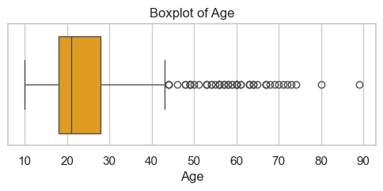

```python
# Boxplot for Age
plt.figure(figsize=(6,2))
sns.boxplot(x=df['Age'], color='orange')
plt.title('Boxplot of Age')
plt.xlabel('Age')
plt.savefig('../plots/5. Boxplot_of_Age.png')
plt.show()
```

The boxplot provides us with a more intense look at the spread of ages among participants. The majority of users are grouped between about 18 and 30 years of age, as we also noticed in the histogram. But there are a number of outliers on the older end, especially above 40 through almost 90. Those outliers imply that some tiny minority of much older clients were included, but they're not in the main distribution. While these outliers are legitimate responses, we will keep in mind that they can influence range- or scale-sensitive models — so we may have to normalize or transform them subsequently.

#### Mental Health Scores

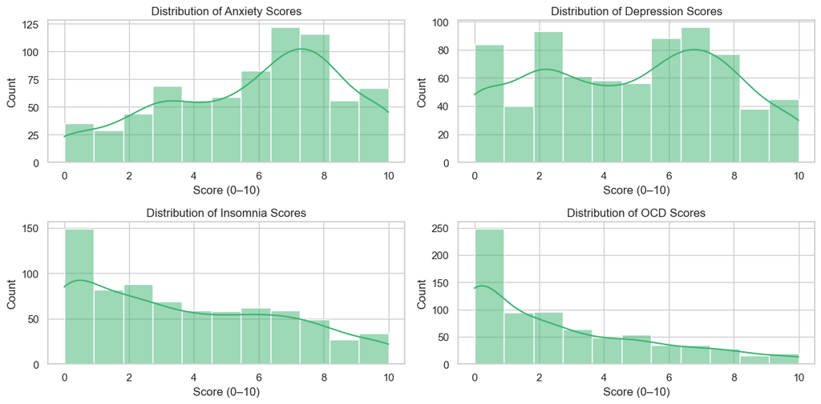

```python
# Converting mental health columns to numeric
mh_scores = ['Anxiety', 'Depression', 'Insomnia', 'OCD']
for col in mh_scores:
    df[col] = pd.to_numeric(df[col], errors='coerce')  # Forcing non-numeric to NaN

# Plotting histograms
plt.figure(figsize=(12, 6))
for i, col in enumerate(mh_scores, 1):
    plt.subplot(2, 2, i)
    sns.histplot(df[col].dropna(), bins=11, kde=True, color='mediumseagreen')
    plt.title(f'Distribution of {col} Scores')
    plt.xlabel('Score (0–10)')
    plt.ylabel('Count')

plt.tight_layout()
plt.savefig('../plots/6. Mental_Health_Scores_Distribution.png')
plt.show()
```

Glancing at the four self-reported scores of mental health distributions, we can already observe some interesting trends among the participants. Anxiety is the most dominating issue, and a very high number of participants have reported scores between 6 and 8. Depression is also patterned but less distributed, with quite an even balance across low to high scores. On the other hand, Insomnia and OCD show a different picture — both are highly biased to the left, i.e., the majority of participants have low levels of these conditions. The majority of users have zero or nearly zero OCD scores, and insomnia is also predominantly between 0 and 3. This difference across mental health conditions is important because it will influence how we build classification thresholds, weight our models, and potentially cluster users in unsupervised analysis. The imbalance especially in OCD may necessitate techniques like class balancing or stratified sampling at later stages of modeling. These trends also provide the foundation for investigation of whether listening behavior or music preferences are associated with higher or lower scores.

#### Favorite Genre

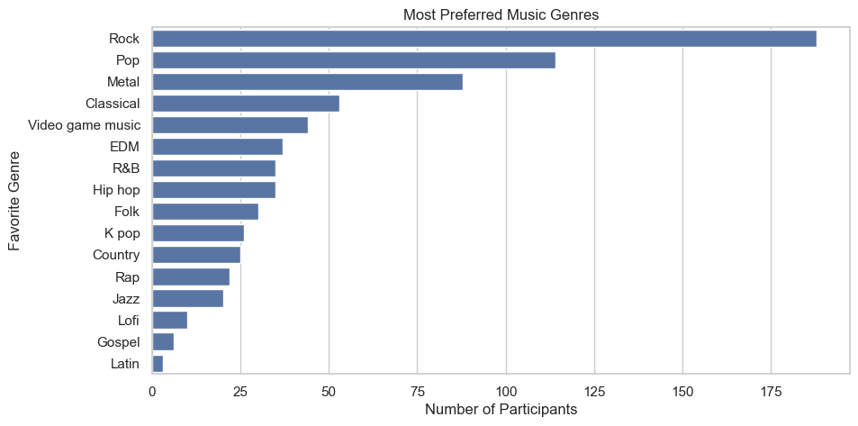

```python
# Countplot of favorite genres
plt.figure(figsize=(10,5))
sns.countplot(data=df, y='Fav genre', order=df['Fav genre'].value_counts().index)
plt.title('Most Preferred Music Genres')
plt.xlabel('Number of Participants')
plt.ylabel('Favorite Genre')
plt.savefig('../plots/7. Most_Preferred_Music_Genres.png')
plt.show()
```